# Cluster Muday lab 72_F3H_PollenTube Data

Molly Davis

2023-05-30

# Introduction

Is my RNA-seq experiment successful? The following markdown tries to determine whether the following RNA-seq data is successfully representing different experiments. The experiments include 3 genotypes (OE3, VF36, ARE) at control and stress temperatures (28C, 34C) in each time point (15min, 30min, 45min, 75min). To determine if the experiments were successful we will be using PCA plots. Variation between gene expression will help us determine if heat conditions have impacted gene expression levels over specific time points and genotypes. We use PCA plots because it clusters samples based on their similarity and is a popular technique for analyzing large data sets containing a high number of dimensions/features per observation.

The Goal: Create PCA plots for all 3 genotypes at control and stress temperatures in each time point (so, this would be 4 PCA plots).

Link to Data sets: https://bitbucket.org/hotpollen/flavonoid-rnaseq/src/main/

Code Resources:

- http://bioconductor.org/packages/devel/bioc/vignettes/DESeq2/inst/doc/DESeq2.html
- https://cran.r-project.org/web/packages/ggfortify/vignettes/plot_pca.html
- https://scienceparkstudygroup.github.io/rna-seq-lesson/05-descriptive-plots/index.html

# Results

```r
# The Purge
rm(list = ls())
```

```r
# Functions
source("Functions.R")
```

## Data Preparation

```r
# Normalization Comment: The DESeq2 model internally corrects for library size, so transformed or normalized values such as counts scaled by library size should not be used as input.
# If you want to normalize use this command: dds <- estimateSizeFactors(dds)
# extract the normalized counts with command: counts_normalised = counts(dds, normalized = TRUE)
# Make sure to open Rproj. first then open markdown files to get the correct working directory: ~/Desktop/analysis-flavonoid-rnaseq/muday-144-analysis/.RData

# Data input:
# Normalization Comment: The DESeq2 model internally corrects for library size, so transformed or normalized values such as counts scaled by library size should not be used as input.
# Make sure to open Rproj. first then open markdown files to get the correct working directory: ~/Desktop/analysis-flavonoid-rnaseq/muday-144-analysis/.RData
rawCounts = read.csv('../results/muday-144-SL5_counts-salmon.txt',sep = "\t",stringsAsFactors = F, header=T, check.names = FALSE, row.names = "gene_name")
rawCounts = rawCounts[,-ncol(rawCounts)] # Remove description column
head(rawCounts,2)
```

```
##             F.28.15.7 F.34.15.7 F.28.30.7 F.34.30.7 F.28.45.7 F.34.45.7
## PRAM_100603         0         0         0         0         0         0
## PRAM_100922         0         0         0         0         0         0
##             F.28.75.7 F.34.75.7 V.28.15.7 V.34.15.7 V.28.30.7 V.34.30.7
## PRAM_100603         0         0         0         0         0         0
## PRAM_100922         0         0         0         0         0         0
##             V.28.45.7 V.34.45.7 V.28.75.7 V.34.75.7 A.28.15.7 A.34.15.7
## PRAM_100603         0         0         0         0         0         0
## PRAM_100922         0         0         0         0         0         0
##             A.28.30.7 A.34.30.7 A.28.45.7 A.34.45.7 A.28.75.7 A.34.75.7
## PRAM_100603         0         0         0         0         0         0
## PRAM_100922         0         0         0         0         0         0
##             V.34.15.8 A.34.30.8 F.34.30.8 V.34.30.8 F.28.75.8 A.28.45.8
## PRAM_100603         0         0         0         0         0         0
## PRAM_100922         0         0         0         0         0         0
##             V.28.45.8 F.28.45.8 F.28.15.8 V.28.15.8 A.28.15.8 F.28.30.8
## PRAM_100603         0         0         0         0         0         0
## PRAM_100922         0         0         0         0         0         0
##             V.34.75.8 F.34.75.8 A.34.75.8 V.34.45.8 A.28.30.8 F.34.15.8
## PRAM_100603         0         0         0         0         0         0
## PRAM_100922         0         0         0         0         0         0
##             V.28.30.8 A.34.15.8 A.34.45.8 V.28.75.8 F.34.45.8 A.28.75.8
## PRAM_100603         0         0         0         0         0         0
## PRAM_100922         0         0         0         0         0         0
##             V.34.30.9 V.28.30.9 V.34.15.9 V.28.15.9 V.34.75.9 V.28.75.9
## PRAM_100603         0         0         0         0         0         0
## PRAM_100922         0         0         0         0         0         0
##             V.34.45.9 V.28.45.9 F.34.30.9 F.28.30.9 F.34.15.9 F.28.15.9
## PRAM_100603         0         0         0         0         0         0
## PRAM_100922         0         0         0         0         0         0
##             F.34.75.9 F.28.75.9 F.34.45.9 F.28.45.9 A.34.30.9 A.28.30.9
## PRAM_100603         0         0         0         0         0         0
## PRAM_100922         0         0         0         0         0         0
##             A.34.15.9 A.28.15.9 A.34.75.9 A.28.75.9 A.34.45.9 A.28.45.9
## PRAM_100603         0         0         0         0         0         0
## PRAM_100922         0         0         0         0         0         0
```

```r
sampleData = makeExperimentMetaDataFrame() # A function from Functions.R script
head(sampleData,2)
```

```
##           genotype time temperature
## F.28.15.7        F   15          28
## F.34.15.7        F   15          34
```

## Sanity Check

```r
# Put the columns of the count data in the same order as rows names of the sample mapping, then make sure it worked
rawCounts <- rawCounts[,unique(rownames(sampleData))]
check <- all(colnames(rawCounts) == rownames(sampleData))
if(check == "TRUE"){
print("The columns of the count data and row names from sampleData are in the same order. Please Continue the analysis!")
}else {
print("The count data and sampleData are not in the same order please fix this before continuing!")
}
```

```
## [1] "The columns of the count data and row names from sampleData are in the same order. Please Continue the analysis!"
```

## Data separation

```r
# Genotype Data from rawCounts
OE3 <- select(rawCounts,contains("F"))
#head(OE3)
VF36 <- select(rawCounts,contains("V"))
#head(VF36)
are <- select(rawCounts,contains("A"))
#head(are)

# sampleData file genotypes
sampleData$type <- rownames(sampleData)
OE3_meta <- dplyr::filter(sampleData, grepl('F', type))
sampleData$type <- rownames(sampleData)
VF36_meta <- dplyr::filter(sampleData, grepl('V', type))
sampleData$type <- rownames(sampleData)
are_meta <- dplyr::filter(sampleData, grepl('A', type))
```

## All genotypes PCA Plot

```
## -- replacing outliers and refitting for 3 genes
## -- DESeq argument 'minReplicatesForReplace' = 7
## -- original counts are preserved in counts(dds)
```

```
##
## out of 21380 with nonzero total read count
## adjusted p-value < 0.1
## LFC > 0 (up)       : 95, 0.44%
## LFC < 0 (down)     : 6, 0.028%
## outliers [1]       : 0, 0%
## low counts [2]     : 7181, 34%
## (mean count < 0)
## [1] see 'cooksCutoff' argument of ?results
## [2] see 'independentFiltering' argument of ?results
##
##
## out of 21380 with nonzero total read count
## adjusted p-value < 0.05
## LFC > 0 (up)       : 84, 0.39%
## LFC < 0 (down)     : 3, 0.014%
## outliers [1]       : 0, 0%
## low counts [2]     : 3989, 19%
## (mean count < 0)
## [1] see 'cooksCutoff' argument of ?results
## [2] see 'independentFiltering' argument of ?results
```

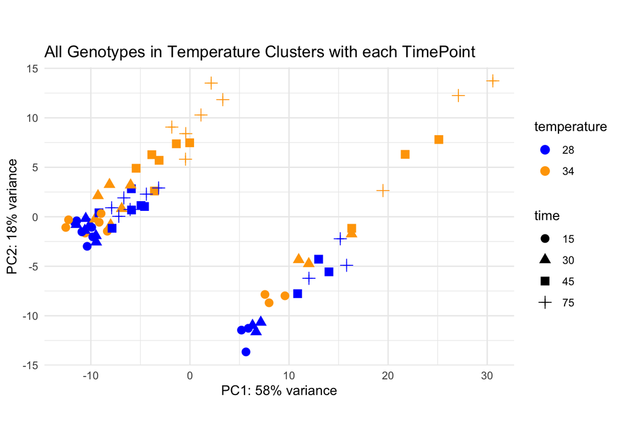

```r
PCA_plots(rawCounts, sampleData, "All Genotypes in Temperature Clusters with each TimePoint")
```

There is unclear reason for separation for certain genotypes in specific times and temperatures. The best next option is to separate the date even further to get a closer look.

## OE3 genotype PCA Plot

```
##
## out of 18639 with nonzero total read count
## adjusted p-value < 0.1
## LFC > 0 (up)       : 43, 0.23%
## LFC < 0 (down)     : 2, 0.011%
## outliers [1]       : 6, 0.032%
## low counts [2]     : 983, 5.3%
## (mean count < 0)
## [1] see 'cooksCutoff' argument of ?results
## [2] see 'independentFiltering' argument of ?results
##
##
## out of 18639 with nonzero total read count
## adjusted p-value < 0.05
## LFC > 0 (up)       : 41, 0.22%
## LFC < 0 (down)     : 1, 0.0054%
## outliers [1]       : 6, 0.032%
## low counts [2]     : 648, 3.5%
## (mean count < 0)
## [1] see 'cooksCutoff' argument of ?results
## [2] see 'independentFiltering' argument of ?results
```

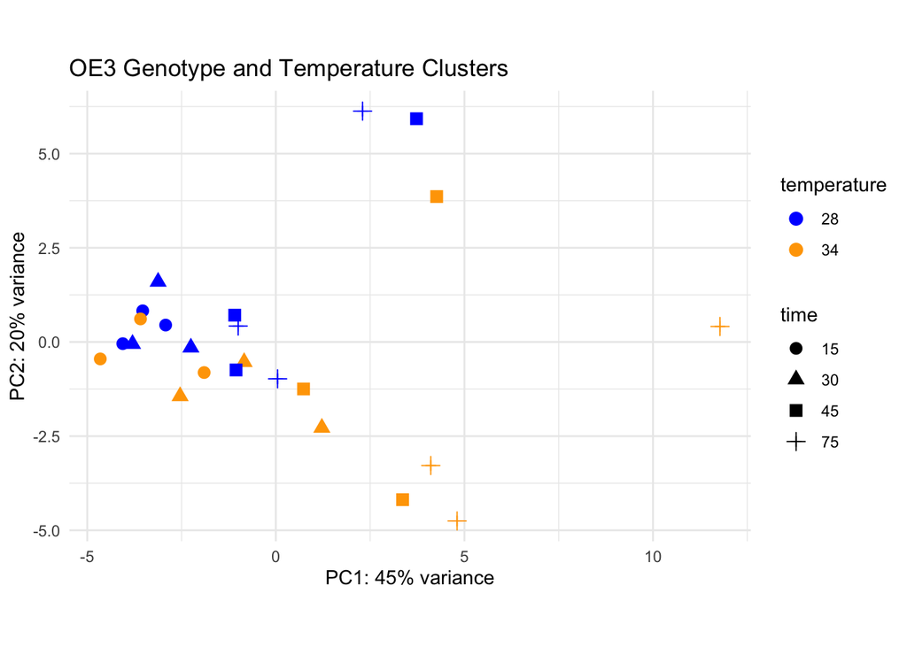

```r
PCA_plots(OE3, OE3_meta, "OE3 Genotype and Temperature Clusters")
```

For OE3 and each experiment there is more variance than clustering happening. This could mean that there isn’t much of a conditional difference to see much clustering on such a small scale.

## VF36 Genotype PCA Plot

```
##
## out of 18505 with nonzero total read count
## adjusted p-value < 0.1
## LFC > 0 (up)       : 43, 0.23%
## LFC < 0 (down)     : 0, 0%
## outliers [1]       : 0, 0%
## low counts [2]     : 0, 0%
## (mean count < 0)
## [1] see 'cooksCutoff' argument of ?results
## [2] see 'independentFiltering' argument of ?results
##
##
## out of 18505 with nonzero total read count
## adjusted p-value < 0.05
## LFC > 0 (up)       : 42, 0.23%
## LFC < 0 (down)     : 0, 0%
## outliers [1]       : 0, 0%
## low counts [2]     : 5784, 31%
## (mean count < 1)
## [1] see 'cooksCutoff' argument of ?results
## [2] see 'independentFiltering' argument of ?results
```

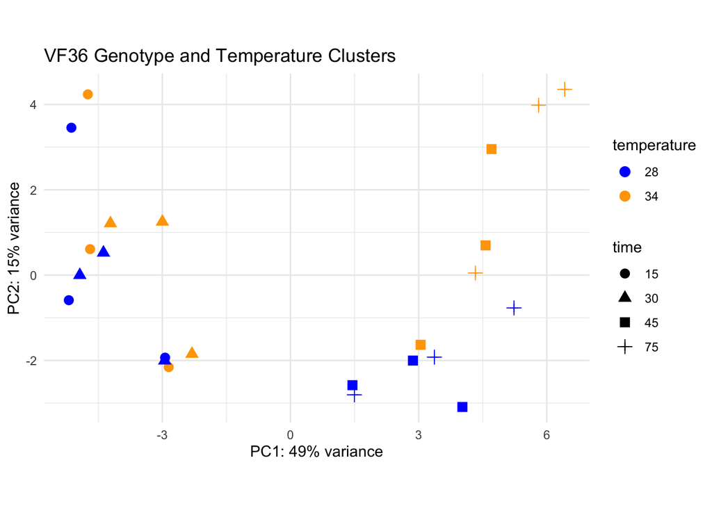

```r
PCA_plots(VF36, VF36_meta, "VF36 Genotype and Temperature Clusters")
```

VF36 PCA Plot has a much larger separation between times and a little clustering for temperature.

## ARE genotype PCA Plot

```
##
## out of 19782 with nonzero total read count
## adjusted p-value < 0.1
## LFC > 0 (up)       : 146, 0.74%
## LFC < 0 (down)     : 7, 0.035%
## outliers [1]       : 2, 0.01%
## low counts [2]     : 6594, 33%
## (mean count < 1)
## [1] see 'cooksCutoff' argument of ?results
## [2] see 'independentFiltering' argument of ?results
##
##
## out of 19782 with nonzero total read count
## adjusted p-value < 0.05
## LFC > 0 (up)       : 131, 0.66%
## LFC < 0 (down)     : 3, 0.015%
## outliers [1]       : 2, 0.01%
## low counts [2]     : 6960, 35%
## (mean count < 1)
## [1] see 'cooksCutoff' argument of ?results
## [2] see 'independentFiltering' argument of ?results
```

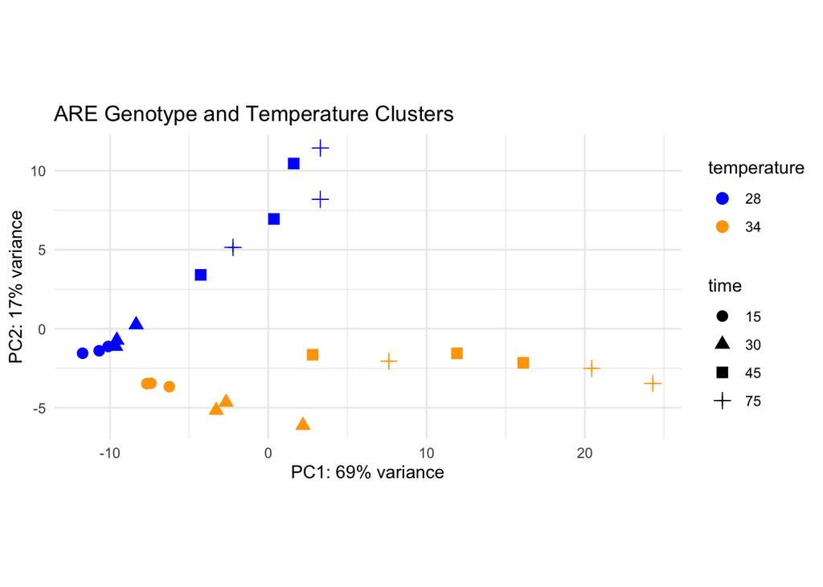

```r
PCA_plots(are, are_meta, "ARE Genotype and Temperature Clusters")
```

The ARE genotype has clear separation and clustering based on temperature and time.

## Save Results and Export as PDF

```r
pca <- run_PCA(rawCounts, sampleData)
```

```
## -- replacing outliers and refitting for 3 genes
## -- DESeq argument 'minReplicatesForReplace' = 7
## -- original counts are preserved in counts(dds)
```

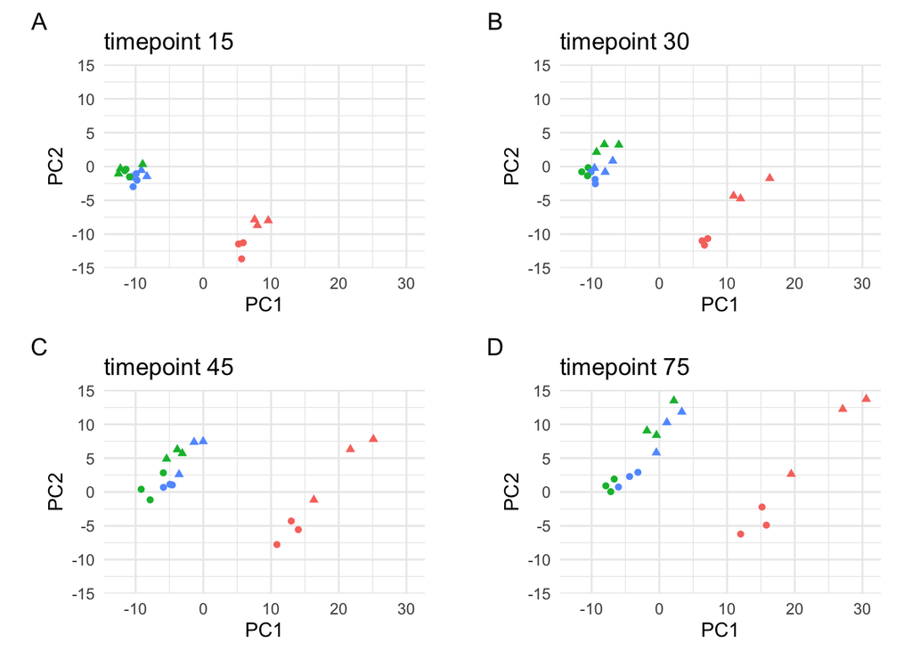

```r
min_pc1 <- min(pca[,"PC1"])
max_pc1 <- max(pca[,"PC1"])
min_pc2 <- min(pca[,"PC2"])
max_pc2 <- max(pca[,"PC2"])

pca_time_15 <- pca %>% filter(time == 15)
pca_time_30 <- pca %>% filter(time == 30)
pca_time_45 <- pca %>% filter(time == 45)
pca_time_75 <- pca %>% filter(time == 75)

tag_it <- tagger()
plot_15 <- plot_PCA(pca_time_15, 15) + lims(x = c(min_pc1, max_pc1), y = c(min_pc2, max_pc2)) + tag_it()
plot_30 <- plot_PCA(pca_time_30, 30) + lims(x = c(min_pc1, max_pc1), y = c(min_pc2, max_pc2)) + tag_it()
plot_45 <- plot_PCA(pca_time_45, 45) + lims(x = c(min_pc1, max_pc1), y = c(min_pc2, max_pc2)) + tag_it()
plot_75 <- plot_PCA(pca_time_75, 75) + lims(x = c(min_pc1, max_pc1), y = c(min_pc2, max_pc2)) + tag_it()
cowplot::plot_grid(plot_15, plot_30, plot_45, plot_75, align = "hv")
```

```r
cowplot::get_legend(plot_15 + theme(legend.position = "bottom"))
```

# Discussion

The PCA Plots are great at clustering and identifying patterns for gene expression. All of the plots don’t have exact separation that you would like to see in results. The goal was to answer these questions for the experiment to be successful:

- Are the samples from the same condition grouped together?
- Are the first two principal components (PC1, PC2) explaining a major percentage of the total variation present in the data set?
- Are the samples from different experimental conditions well separated by PC1 and PC2?

If “yes” is the answer to these questions, then the experiment can be considered a success.

If “no” is the answer to these questions, then the experiments can be considered unsuccessful and may require more extreme conditions or different features.

This study had issues with mislabeled samples. This could be an issue and also that the experiment could require more extreme heat conditions to see a large separation of gene expression. The results were very informative on how we should move forward with the rnaseq data or how to perform the experiment/study for next time.

# Conclusion